# ioslides template

August 08 2017

## Outline

### (non-incremental, no sub-points)

Main Learning Outcomes  
This presentation will cover:

- General CSS Styles
- Lists
- Links
- Code blocks
- Images
- Videos

## Outline

### (non-incremental, with sub-points)

This presentation will cover:

- General CSS Styles
- Lists
- **Incremental lists** *this should be a sub-point*
- **Non-incremental lists** *this should be a sub-point*
- *please note that sub-points are not working when you override the incremental: true with > in the YAML information.*
- Links
- Code blocks
- Images
- Videos

## Section Divider Title

### Subtitle (optional)

## CSS Styles - General

CSS for this ioslides presentation:

This is `inline code` in this ioslides presentation.

This is a Keyword.

This is a *Italic text* using * or _

This is a **Bold text** using ** or __

This is strikethrough text using ~~

This is a named link to [RStudio](http://rmarkdown.rstudio.com).

Or the link in full http://rmarkdown.rstudio.com.

## CSS Styles - Lists

### General Style

This slide shows the CSS unordered list styles for this ioslides presentation.

We have set incremental as "true" for the default in the YAML, which means the list points will release one by one.

Unordered lists will look like this. We have made them round as the default.

- Item 1
- Item 2
- Item 3

## CSS Styles - Lists

### Unordered lists

This slide shows the CSS unordered list styles for this ioslides presentation.

**Non-Incremental** unordered lists: A-B show bullet points that all show up at once (i.e. do not incrementally release). In the .rmd file, you will see that each bullet point has a ">" symbol in front of it to override the *incremental: true* setting in the YAML information.

- A
- B

**Incremental** unordered lists: C-D show bullet points that incrementally release. In the .rmd file, you will see that these will not have a ">"" in front of the bullet point.

- C
- D

## CSS Styles - Lists

### Ordered lists

This slide shows the CSS ordered list styles for this ioslides presentation.

Ordered lists:

1. Item 1
2. Item 2
3. Item 3
   1. Item 3a
   2. Item 3b

## CSS Styles - links

How to include a link in the .rmd file:

```
[Link Name](web address)
```

- Github
- StackOverflow
- Reddit

Markdown help:

- [Mastering Markdown](https://guides.github.com/features/mastering-markdown/)
- [Pandoc Markdown](http://rmarkdown.rstudio.com/authoring_pandoc_markdown.html)

## CSS Styles - code blocks

An example R code block (that is not code yet)

```
x + 2 = y

z = q
```

## CSS Styles - tables

An example of a table and the css table styling.

| Heading 0 | Heading 1 | Heading 2 | Heading 3 | Heading 4 |
| --- | --- | --- | --- | --- |
| Row Title 1 | Cell Text 1 | Cell Text 2 | Cell Text 3 | Cell Text 4 |
| Row Title 2 |  |  | More text 2 |  |
| Row Title 3 |  |  |  | More text 3 |
| Row Title 4 |  |  |  |  |

## Images

The next two slides (the second & third under the "Images" heading - see the .rmd file) include embedded images.

You will need to make sure the image files are in the correct folder as refered to in the .rmd file path so the ioslides will knit correctly.

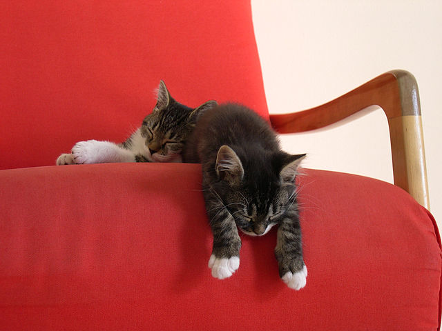

By Stephan Brunet Macphreak - http://macphreak.com, CC BY-SA 3.0, https://commons.wikimedia.org/w/index.php?curid=4124375

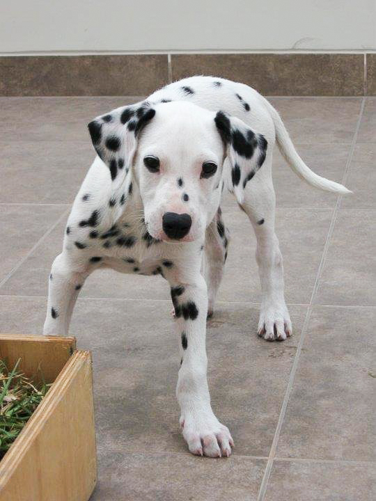

By Carlos Estrada Dejo - Own work, CC BY-SA 3.0, https://commons.wikimedia.org/w/index.php?curid=25644223

## Slide that builds all elements (not just text)

- This is an slide that shows how you can build all elements on a slide…not just text
- To do this, you need to include {.build} after the slide header in the .rmd file
- And now a picture…

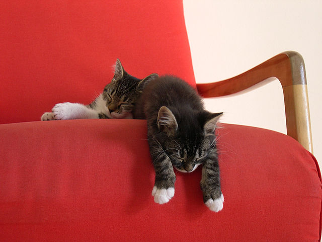

- By Stephan Brunet Macphreak - http://macphreak.com, CC BY-SA 3.0, https://commons.wikimedia.org/w/index.php?curid=4124375

## Videos

The next slide (the second under the "Videos" heading - see the .rmd file) includes an embedded You Tube video. You will need to be connected to the internet for this to knit correctly.

[video not shown]

[Best Of Cute Golden Retriever Puppies Compilation](https://youtu.be/a6KGPBflhiM)

## Boxes

This section show some common boxes for use, such as the "Get Started" box:

### Statistical Thinking (*activity box*)

With the person next to you:

- Pose some research questions about XYZ.
- For each one, sketch what type of graphical summary you would use

[Another link - Google](https://www.google.com)  
This slide shows an activity box, called "Statistical Thinking"

### Definition

This slide shows definition box.

## Icons for use

Find more examples here: [Font Awesome Cheatsheet](http://fontawesome.io/cheatsheet/)

## LaTeX

You can also type LaTeX into the rmd file.

For example:

Even if \[ \frac{a_1}{b_1} < \frac{c_1}{d_1} \]

and \[ \frac{c_1}{d_1} < \frac{c_2}{d_2} \]

It is possible to have

\[ \frac{a_1+ a_2}{b_1 +b_2} > \frac{c_1+c_2}{d_1 +d_2} \]

## LaTeX (cont.)

Definition of mean and median

Given data \(x_{1}, x_{2}, \ldots, x_{n}\), the mean is

\[ \bar{x} = \frac{1}{n} \sum_{i=1}^{n} x_{i} \]

Given the ordered data \(x_{(1)}, x_{(2)}, \ldots, x_{(n)}\), the median is

\[ \tilde{x} = x_{(\frac{n+1}{2})} \;\;\;\;\; (where \; n \; is \; odd) \]

\[ \tilde{x} = \frac{ x_{(\frac{n}{2})} + x_{(\frac{n}{2} + 1)} }{2} \;\;\;\; (where \; n \; is \; even) \]

## Copyright

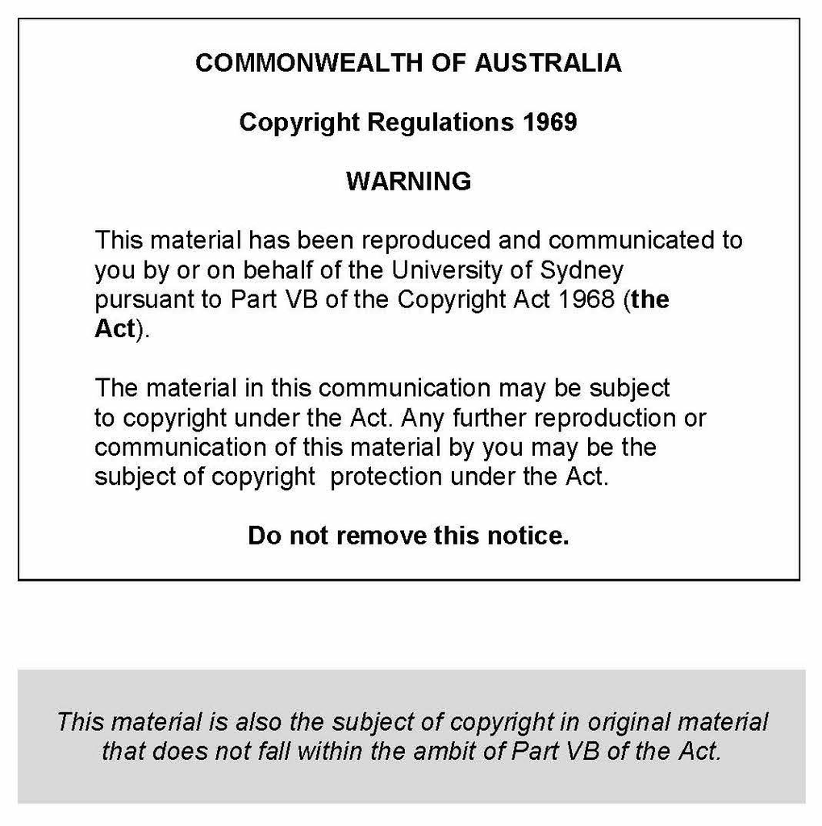